# Eighth Week: Text Analysis in R

To be, or not to be

امین رخشا ۹۵۱۰۹۳۱۵

2018-05-05 02:58:59

> با استفاده از بسته gutenberg داده های لازم را به دست آورید و به سوالات زیر پاسخ دهید.

کارهای اولیه

```r
library(gutenbergr)
library(stringr)
library(tidytext)
library(dplyr)
library(tidyr)
library(ggplot2)
library(ggthemes)
library(scales)
library(highcharter)
theme_set(theme_gdocs())
```

۱. چارلز دیکنز نویسنده معروف انگلیسی بالغ بر چهارده رمان (چهارده و نیم) نوشته است. متن تمامی کتاب های او را دانلود کنید و سپس بیست لغت برتر استفاده شده را به صورت یک نمودار ستونی نمایش دهید. (طبیعتا باید ابتدا متن را پاکسازی کرده و stopping words را حذف نمایید تا به کلماتی که بار معنایی مشخصی منتقل می کنند برسید.)

```r
bookCodes = c(580, 730, 967, 700, 917, 968, 821, 766, 1023, 786, 963, 1400, 883, 564)
# View(gutenberg_metadata %>% filter(gutenberg_id %in% novelCodes))
# books = gutenberg_download(bookCodes)
# saveRDS(books, file="books.Rda")
books = readRDS(file="books.Rda")

words = books$text %>%
  str_replace_all("[[:punct:]]", " ") %>%
  str_replace_all("\"", " ") %>%
  str_split_fixed("[\\s]", n = Inf) %>%
  as.data.frame(stringsAsFactors = F)
colnames(words) = 1:72
words = cbind(books, words) %>%
  select(-text) %>%
  mutate(line = row_number()) %>%
  gather(key = 'index', value = 'word', 2:73) %>%
  mutate(index = as.numeric(index)) %>%
  arrange(line, index) %>%
  select(-line, -index) %>%
  filter(str_length(word) > 1)


wordFreq = words$word %>%
  str_to_lower() %>%
  table() %>%
  as.data.frame(stringsAsFactors = F)
colnames(wordFreq) = c('word', 'count')
aux <- c('don', 'll', 'isn', 'aren', 're', 'wouldn', 'couldn')
wordFreq = wordFreq %>%
  filter(!str_to_lower(word) %in% stop_words$word) %>%
  filter(!word %in% aux) %>%
  arrange(desc(count))

topWords = wordFreq %>%
  top_n(n = 20, count)


hchart(topWords, type = 'column', hcaes(x = word, y = count), name = 'Count')
```

[interactive chart not shown]

۲. ابر لغات ۲۰۰ کلمه پرتکرار در رمان های چارلز دیکنز را رسم نمایید. این کار را با بسته wordcloud2 انجام دهید. برای دانلود می توانید به لینک زیر مراجعه کنید.

https://github.com/Lchiffon/wordcloud2

با استفاده از عکسی که در ابتدا متن آمده ابر لغاتی مانند شکل زیر رسم کنید. (راهنمایی: از ورودی figpath در دستور wordcloud2 استفاده نمایید.مثالی در زیر آورده شده است.)

```r
topWords = wordFreq %>%
  top_n(n = 200, count)
library(wordcloud2)
wordcloud2(topWords)
```

[interactive chart not shown]

[interactive chart not shown]

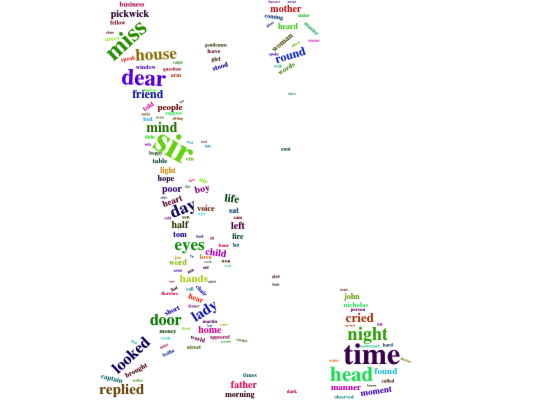

```r
wordcloud2(topWords, figPath = 'fig.png', size = 0.2)
```

۳. اسم پنج شخصیت اصلی در هر رمان دیکنز را استخراج کنید و با نموداری تعداد دفعات تکرار شده بر حسب رمان را رسم نمایید. (مانند مثال کلاس در رسم اسامی شخصیت ها در سری هر پاتر)

کلماتی که با حروف کوچک آن ها موجود نیست را به عنوان اسم شناسایی می کنیم

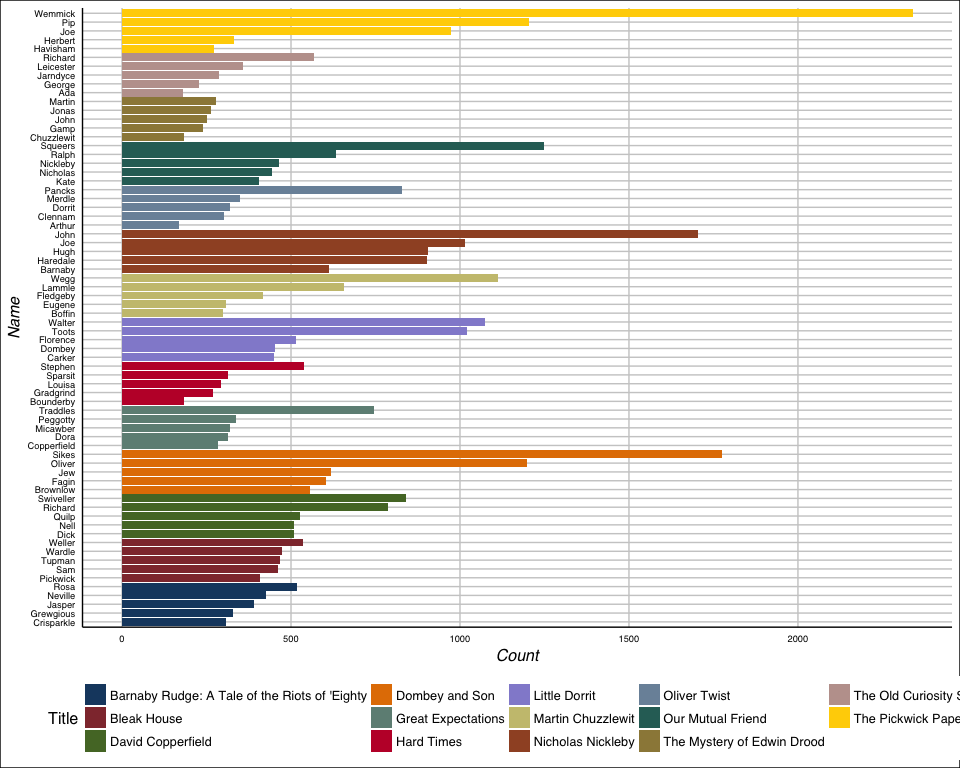

```r
wordFreqByBook = words %>%
  filter(!str_to_lower(word) %in% stop_words$word) %>%
  filter(!word %in% aux) %>%
  group_by(gutenberg_id, word) %>%
  summarise(count = n()) %>%
  ungroup()
names = wordFreqByBook %>%
  filter(!str_to_lower(word) %in% stop_words$word) %>%
  filter(!str_to_lower(word) %in% word) %>%
  rename(name = word)

names = left_join(names,
                  gutenberg_metadata %>% select(gutenberg_id, title))

topNames = names %>%
  group_by(title) %>%
  top_n(5, count)


ggplot(topNames, aes(x = paste(title, str_pad(count, 5, pad = "0"), name), y = count, fill = title)) +
  geom_bar(stat = 'identity') +
  scale_x_discrete(labels = topNames$name) +
  scale_fill_stata() +
  coord_flip() +
  theme(legend.position="bottom", legend.direction = 'horizontal',
        axis.text=element_text(size=7)) +
  labs(x = 'Name', y = 'Count', fill = 'Title')
```

۴. در بسته tidytext داده ایی به نام sentiments وجود دارد که فضای احساسی لغات را مشخص می نماید. با استفاده از این داده نمودار ۲۰ لغت برتر negative و ۲۰ لغت برتر positive را در کنار هم رسم نمایید. با استفاده از این نمودار فضای حاکم بر داستان چگونه ارزیابی می کنید؟ (به طور مثال برای کتاب داستان دو شهر فضای احساسی داستان به ترتیب تکرر در نمودار زیر قابل مشاهده است.)

نمودارها را در زیر میبینید. به طور کلی هر چه تعدا کلمات مثبت بیشتر باشد، فضای کتاب مثبت و شادتر است. که براساس نمودارهای زیر به سادگی قابل فهم است. به طور کلی لغات مثبت بیشتر به نظر می آیند.

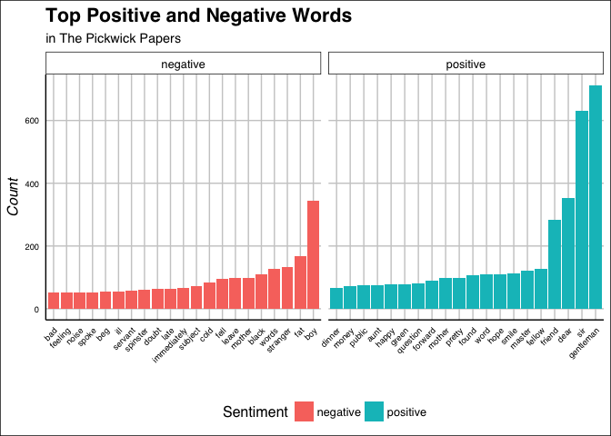

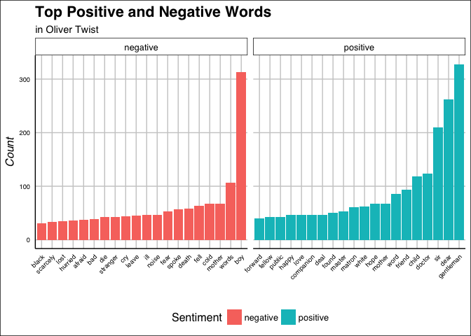

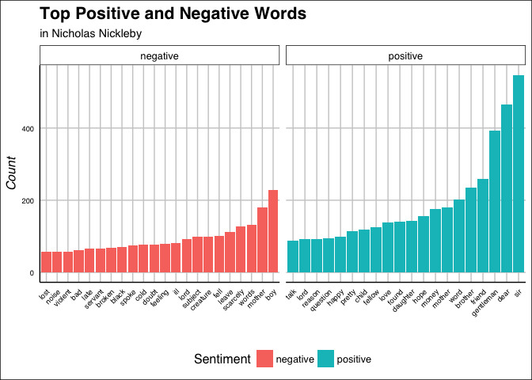

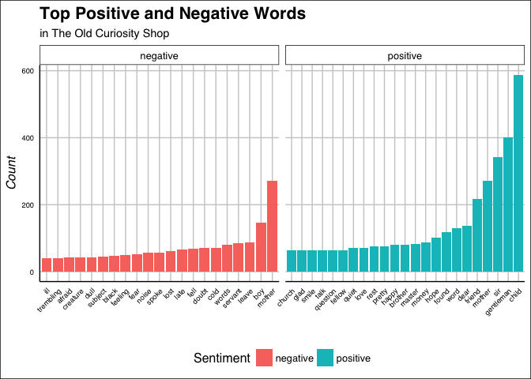

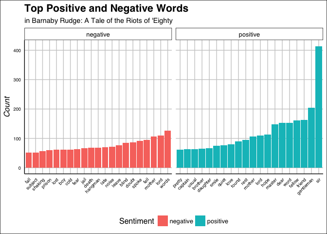

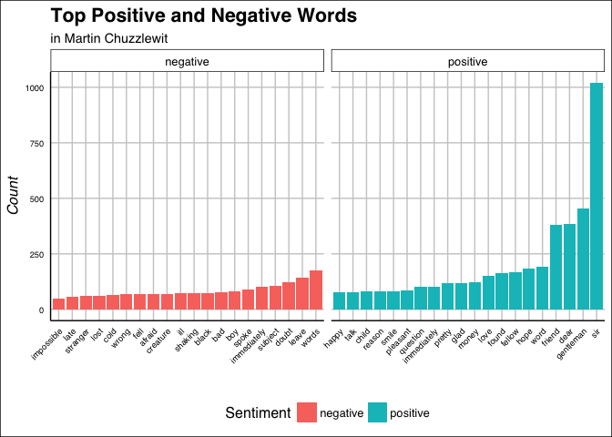

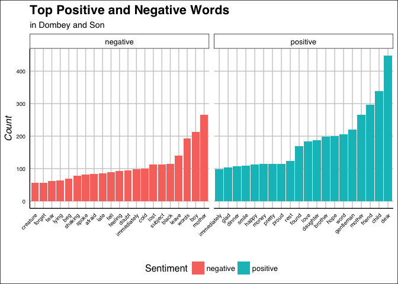

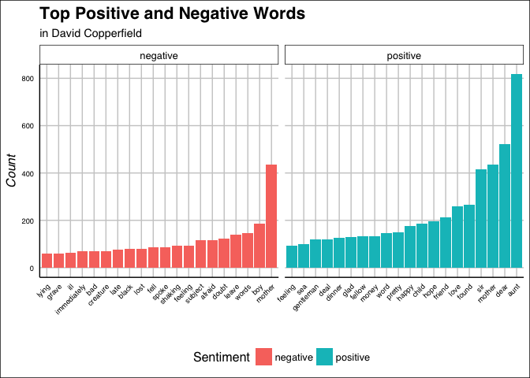

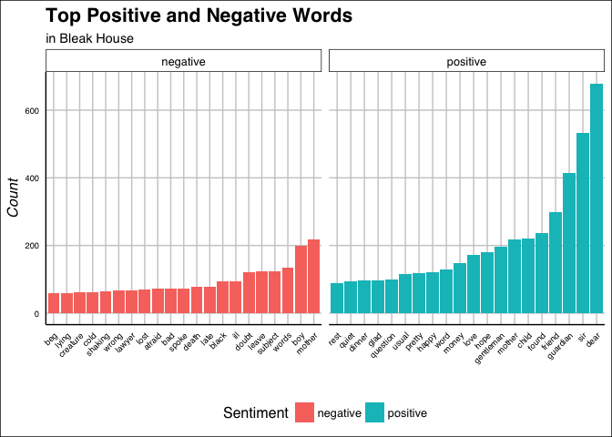

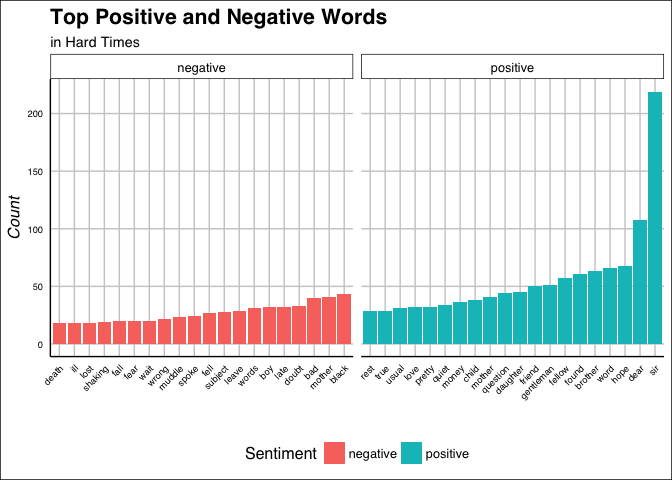

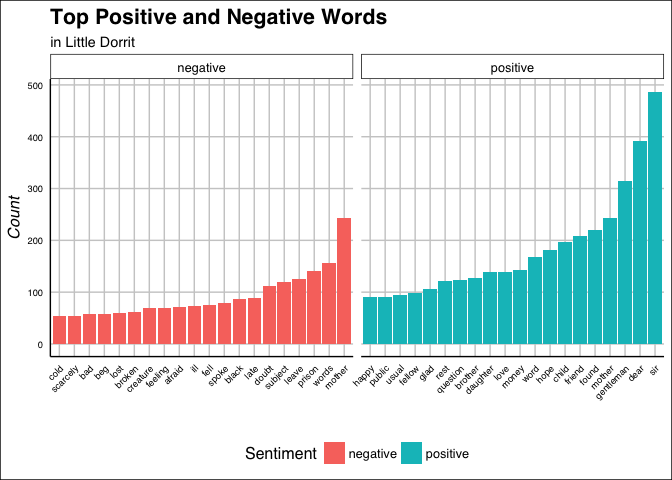

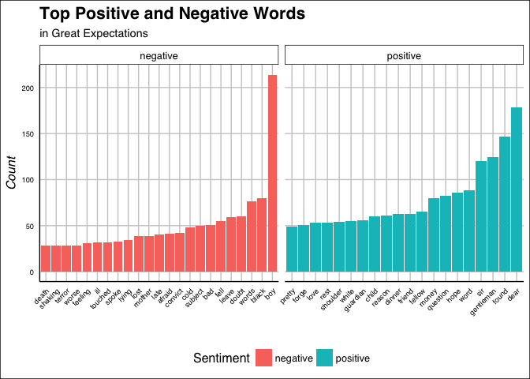

[2 more figures not shown]

```r
nrcPosNeg = sentiments %>%
  filter(lexicon == 'nrc', sentiment %in% c('negative', 'positive')) %>%
  select(word, sentiment)

for(code in bookCodes) {
  title = gutenberg_metadata$title[gutenberg_metadata$gutenberg_id == code]

  np = wordFreqByBook %>%
    filter(gutenberg_id == code) %>%
    filter(word %in% nrcPosNeg$word)
  np = left_join(np, nrcPosNeg, by = 'word')

  topNP = np %>%
    group_by(sentiment) %>%
    top_n(20, count) %>%
    ungroup() %>%
    arrange(desc(count)) %>%
    mutate(index = row_number())

  p = ggplot(topNP, aes(x = reorder(word, count), y = count, fill = sentiment)) +
    geom_bar(stat = 'identity', position = 'dodge') +
    facet_grid(.~sentiment, scale = "free") +
    theme(axis.text = element_text(size = 7),
          axis.text.x = element_text(hjust = 1, vjust = 1, angle = 45),
          legend.position="bottom", legend.direction = 'horizontal') +
    labs(x = '', y = 'Count', fill = 'Sentiment',
         title = 'Top Positive and Negative Words', subtitle = paste('in', title))
  print(p)
}
```

۵. متن داستان بینوایان را به ۲۰۰ قسمت مساوی تقسیم کنید. برای هر قسمت تعداد لغات positive و negative را حساب کنید و سپس این دو سری زمانی را در کنار هم برای مشاهده فضای احساسی داستان رسم نمایید.

چون تعداد کلماتی که مثبت یا منفی بودنشان معلوم است در قطعات معلوم نیست، برای نرمال کردن، فراوانی را بر کل کلماتی که این موضوع برایشان مشخص است. تقسیم میکنیم

```r
miserables_id = 135
# miserablesBook = gutenberg_download(miserables_id)
# saveRDS(miserablesBook, file="miserables.Rda")
miserablesBook = readRDS(file="miserables.Rda")
miserablesWords = miserablesBook$text %>%
  str_replace_all("[[:punct:]]", " ") %>%
  str_replace_all("\"", " ") %>%
  str_split("[\\s]+") %>%
  unlist() %>%
  as.data.frame(stringsAsFactors = F)
colnames(miserablesWords) = 'word'
miserablesWords = miserablesWords %>%
  filter(str_length(word) > 0) %>%
  mutate(part = ceiling(row_number() * 200 / n())) %>%
  mutate(word = str_to_lower(word))

nrcSentiments = sentiments %>%
  filter(lexicon == 'nrc') %>%
  select(word, sentiment)

miserablesWords = inner_join(miserablesWords, nrcPosNeg, by = 'word')

storyMood = miserablesWords %>%
  group_by(part, sentiment) %>%
  summarise(count = n()) %>%
  group_by(part) %>%
  mutate(prop = 100 * count / sum(count)) %>%

  ungroup()

hchart(storyMood, type = 'line', hcaes(x = part, y = prop, group = sentiment)) %>%
  hc_colors(colors = c('#e84118', '#4cd137'))
```

[interactive chart not shown]

۶. ابتدا ترکیبات دوتایی کلماتی که پشت سر هم می آیند را استخراج کنید و سپس نمودار ۳۰ جفت لغت پرتکرار را رسم نمایید.

```r
filteredPairs = words %>%
  mutate(word = str_to_lower(word)) %>%
  rename(word1 = word) %>%
  mutate(word2 = lead(word1)) %>%
  filter(!word1 %in% stop_words$word) %>%
  filter(!word2 %in% stop_words$word)

filteredPairsStat = filteredPairs %>%
  group_by(word1, word2) %>%
  summarise(count = n()) %>%
  arrange(desc(count)) %>%
  ungroup()

topPairs = filteredPairsStat %>% top_n(30, wt = count)

hchart(topPairs, type = 'bar', hcaes(x = paste(word1, word2), y = count), name = 'Count') %>%
  hc_xAxis(title = list(text = NA))
```

[interactive chart not shown]

۷. جفت کلماتی که با she و یا he آغاز می شوند را استخراج کنید. بیست فعل پرتکراری که زنان و مردان در داستان های دیکنز انجام می دهند را استخراج کنید و نمودار آن را رسم نمایید.

این کار را انجام می دهیم. نمودار آخر کلمات را برحسب نسبت استفاده سان در بین زنان و مردان نشان میدهد

```r
pairs = words %>%
  mutate(word = str_to_lower(word)) %>%
  rename(word1 = word) %>%
  mutate(word2 = lead(word1)) %>%
  filter(!word2 %in% stop_words$word) %>%
  filter(!word2 %in% aux)

pairStat = pairs %>%
  group_by(word1, word2) %>%
  summarise(count = n()) %>%
  arrange(desc(count)) %>%
  ungroup()

hePairs = pairStat %>%
  filter(word1 == 'he') %>%
  mutate(prop = count / sum(count)) %>%
  top_n(20, count)

shePairs = pairStat %>%
  filter(word1 == 'she') %>%
  mutate(prop = count / sum(count)) %>%
  top_n(20, count)

heshePairs = rbind(hePairs, shePairs)

topVerbs = full_join(hePairs %>% select(word2, prop),
                     shePairs%>% select(word2, prop),
                     by = 'word2') %>%
  rename(heProp = prop.x, sheProp = prop.y)
topVerbs[is.na(topVerbs)] = 0
topVerbs = topVerbs %>%
  mutate(ratio = heProp / sheProp)

heshePairs = rbind(hePairs, shePairs)
heshePairs = left_join(heshePairs, topVerbs)

hchart(hePairs, type = 'bar', hcaes(x = word2, y = count)) %>%
  hc_xAxis(title = list(text = "")) %>%
  hc_title(text = 'Most Common Verbs For Men')
```

[interactive chart not shown]

```r
hchart(shePairs, type = 'bar', hcaes(x = word2, y = count)) %>%
  hc_xAxis(title = list(text = "")) %>%
  hc_title(text = 'Most Common Verbs For Women')
```

[interactive chart not shown]

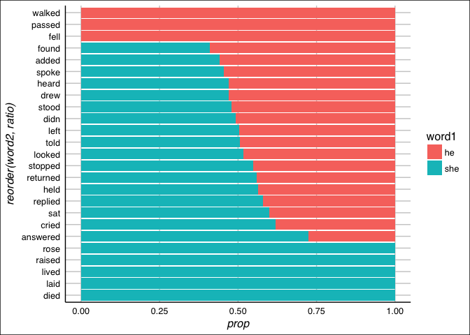

```r
ggplot(heshePairs, aes(x = reorder(word2, ratio), y = prop, fill = word1)) +
  geom_bar(stat = 'identity', position = 'fill') +
  coord_flip()
```

۸. برای کتاب های دیکنز ابتدا هر فصل را جدا کنید. سپی برای هر فصل 1-gram, 2-gram را استخراج کنید. آیا توزیع N-gram در کارهای دیکنز یکسان است؟ با رسم نمودار هم این موضوع را بررسی کنید.

استخراج برای فصل ها

```r
words = words %>%
  group_by(gutenberg_id) %>%
  mutate(chapter = as.numeric(str_detect(str_to_lower(word), 'chapter'))) %>%
  mutate(chapter = cumsum(chapter))

chaptersText = words %>%
  filter(chapter > 0) %>%
  mutate(word = str_to_lower(word)) %>%
  group_by(gutenberg_id, chapter) %>%
  summarise(text = paste(word, sep = ' ', collapse = ' '), count = n()) %>%
  filter(count > 30)

booksText = words %>%
  mutate(word = str_to_lower(word)) %>%
  group_by(gutenberg_id) %>%
  summarise(text = paste(word, sep = ' ', collapse = ' '))


library(ngram)
chaptersNgramStat = list()
for(i in 1:nrow(chaptersText)) {
  text = chaptersText[i,]$text %>% as.character()
  ng1 = ngram(as.character(text), n = 1)
  ng2 = ngram(as.character(text), n = 2)
  s1 <- get.phrasetable(ng1) %>%
    mutate(n = 1) %>%
    filter(!str_trim(ngrams) %in% stop_words$word) %>%
    filter(!str_trim(ngrams) %in% aux)
  s2 <- get.phrasetable(ng2) %>%
    mutate(n = 2) %>%
    separate(ngrams, c("word1", "word2"), sep = " ") %>%
    filter(!word1 %in% stop_words$word) %>%
    filter(!word2 %in% stop_words$word) %>%
    mutate(ngrams = paste(word1, word2)) %>%
    select(-word1, -word2)
  summary = rbind(s1,s2)
  summary = summary %>% select(-freq)
  colnames(summary) = c('ngram', 'prop', 'n')
  id = chaptersText[i,]$gutenberg_id
  ch = chaptersText[i,]$chapter
  summary = summary %>% mutate(gutenburg_id = id, chapter = ch)
  chaptersNgramStat[[i]] = summary
}
chaptersNgramStat = plyr::rbind.fill(chaptersNgramStat)
chaptersNgramStat = chaptersNgramStat %>% mutate(author = 'Dickens')
```

برای بررسی برابری از تست chi squared استفاده می کنیم که نتیجه نشان میدهد یکسان نیستند

```r
ngramStat = data.frame(ngram = character(0), n = numeric(0), stringsAsFactors = F)
for(code in bookCodes) {
  text = booksText %>% filter(gutenberg_id == code) %>% .$text %>% as.character()
  ng1 = ngram(as.character(text), n = 1)
  ng2 = ngram(as.character(text), n = 2)
  s1 <- get.phrasetable(ng1) %>%
    mutate(n = 1) %>%
    filter(!str_trim(ngrams) %in% stop_words$word) %>%
    filter(!str_trim(ngrams) %in% aux)
  s2 <- get.phrasetable(ng2) %>%
    mutate(n = 2) %>%
    separate(ngrams, c("word1", "word2"), sep = " ") %>%
    filter(!word1 %in% stop_words$word) %>%
    filter(!word2 %in% stop_words$word) %>%
    mutate(ngrams = paste(word1, word2)) %>%
    select(-word1, -word2)
  summary = rbind(s1,s2)
  summary = summary %>% select(-freq)
  colnames(summary) = c('ngram', code, 'n')
  ngramStat = full_join(ngramStat, summary) %>% distinct()
}
testData <- ngramStat %>%
             select(-ngram, -n)
testData[is.na(testData)] = 0
testData = testData * 100000000
# chisq.test(testData)
saveRDS(testData, 'booksComparison.rds')
```

```
##
##  Pearson's Chi-squared test
##
## data:  readRDS("booksComparison.rds")
## X-squared = 2306600000, df = 3546700, p-value < 2.2e-16
```

نمودار

```r
ngramStat$total = rowSums(ngramStat %>% select(-ngram, -n))

plotData = ngramStat %>%
  group_by(n) %>%
  top_n(5, total) %>%
  arrange(total) %>%
  ungroup() %>%
  gather(key = 'gutenberg_id', value = 'prop', 3:15) %>%
  mutate(gutenberg_id = as.numeric(gutenberg_id)) %>%
  left_join(gutenberg_metadata %>% select(gutenberg_id, title))

dickensBooksComparison = hchart(plotData, type = 'column', hcaes(x = ngram, y = prop, group = title))
dickensBooksComparison
saveRDS(dickensBooksComparison, 'dickensBooksComparison.rds')
```

[interactive chart not shown]

۹. برای آثار ارنست همینگوی نیز تمرین ۸ را تکرار کنید. آیا بین آثار توزیع n-grams در بین آثار این دو نویسنده یکسان است؟

مشابه ۸

```r
austinsBookCodes = c(105,   121,   141,   158,   161,   946,  1212,  1342)
# austinBooks = gutenberg_download(austinsBookCodes)
# saveRDS(austinBooks, file = "austinBooks.rds")
austinBooks = readRDS(file = "austinBooks.rds")

austinWords = austinBooks$text %>%
  str_replace_all("[[:punct:]]", " ") %>%
  str_replace_all("\"", " ") %>%
  str_split_fixed("[\\s]", n = Inf) %>%
  as.data.frame(stringsAsFactors = F)
colnames(austinWords) = 1:61
austinWords = cbind(austinBooks, austinWords) %>%
  select(-text) %>%
  mutate(line = row_number()) %>%
  gather(key = 'index', value = 'word', 2:62) %>%
  mutate(index = as.numeric(index)) %>%
  arrange(line, index) %>%
  select(-line, -index) %>%
  filter(str_length(word) > 1) %>%
  mutate(word = str_to_lower(word))

austinWords = austinWords %>%
  group_by(gutenberg_id) %>%
  mutate(chapter = as.numeric(str_detect(str_to_lower(word), 'chapter'))) %>%
  mutate(chapter = cumsum(chapter))

austinChaptersText = austinWords %>%
  filter(chapter > 0) %>%
  mutate(word = str_to_lower(word)) %>%
  group_by(gutenberg_id, chapter) %>%
  summarise(text = paste(word, sep = ' ', collapse = ' '), count = n()) %>%
  filter(count > 30)

austinChaptersNgramStat = list()
for(i in 1:nrow(austinChaptersText)) {
  text = austinChaptersText[i,]$text %>% as.character()
  ng1 = ngram(as.character(text), n = 1)
  ng2 = ngram(as.character(text), n = 2)
  s1 <- get.phrasetable(ng1) %>%
    mutate(n = 1) %>%
    filter(!str_trim(ngrams) %in% stop_words$word) %>%
    filter(!str_trim(ngrams) %in% aux)
  s2 <- get.phrasetable(ng2) %>%
    mutate(n = 2) %>%
    separate(ngrams, c("word1", "word2"), sep = " ") %>%
    filter(!word1 %in% stop_words$word) %>%
    filter(!word2 %in% stop_words$word) %>%
    mutate(ngrams = paste(word1, word2)) %>%
    select(-word1, -word2)
  summary = rbind(s1,s2)
  summary = summary %>% select(-freq)
  colnames(summary) = c('ngram', 'prop', 'n')
  id = austinChaptersText[i,]$gutenberg_id
  ch = austinChaptersText[i,]$chapter
  summary = summary %>% mutate(gutenburg_id = id, chapter = ch)
  austinChaptersNgramStat[[i]] = summary
}
austinChaptersNgramStat = plyr::rbind.fill(austinChaptersNgramStat)
austinChaptersNgramStat = austinChaptersNgramStat %>% mutate(author = 'Austin')
```

با تست chi squared برابری توزیع را بین دو نویسنده بررسی می کنیم که نتیجه نشان می دهد برابر نیستند

```r
authors <- c('Austin', 'Dickens')
authorsText = data.frame(author = authors,
           text = c(
             paste(austinWords$word, sep = ' ', collapse = ' '),
             paste(str_to_lower(words$word), sep = ' ', collapse = ' ')
           ))


authorsNgramStat = data.frame(ngram = character(0), n = numeric(0), stringsAsFactors = F)
for(a in authors) {
  text = authorsText %>% filter(author == a) %>% .$text %>% as.character()
  ng1 = ngram(as.character(text), n = 1)
  ng2 = ngram(as.character(text), n = 2)
  s1 <- get.phrasetable(ng1) %>%
    mutate(n = 1) %>%
    filter(!str_trim(ngrams) %in% stop_words$word) %>%
    filter(!str_trim(ngrams) %in% aux)
  s2 <- get.phrasetable(ng2) %>%
    mutate(n = 2) %>%
    separate(ngrams, c("word1", "word2"), sep = " ") %>%
    filter(!word1 %in% stop_words$word) %>%
    filter(!word2 %in% stop_words$word) %>%
    mutate(ngrams = paste(word1, word2)) %>%
    select(-word1, -word2)
  summary = rbind(s1,s2)
  summary = summary %>% select(-freq)
  colnames(summary) = c('ngram', a, 'n')
  authorsNgramStat = full_join(authorsNgramStat, summary) %>% distinct()
}
testData <- authorsNgramStat %>%
  select(-ngram, -n)
testData[is.na(testData)] = 0
testData = testData * 1000000

# chisq.test(testData)
saveRDS(testData, 'authorsComparisonTest.rds')
```

```
##
##  Pearson's Chi-squared test
##
## data:  readRDS("authorsComparisonTest.rds")
## X-squared = 346590, df = 306970, p-value < 2.2e-16
```

کارهای اولیه

```r
authorsNgramStat$total = rowSums(authorsNgramStat %>% select(-ngram, -n))

plotData = authorsNgramStat %>%
  group_by(n) %>%
  top_n(5, total) %>%
  arrange(total) %>%
  ungroup() %>%
  gather(key = 'author', value = 'prop', 3:4)

authorsComparison = hchart(plotData, type = 'column', hcaes(x = ngram, y = prop, group = author))
authorsComparison
saveRDS(authorsComparison, file = 'authorsComparison.rds')
```

[interactive chart not shown]

۱۰. بر اساس دادهایی که در تمرین ۸ و ۹ از آثار دو نویسنده به دست آوردید و با استفاده از N-gram ها یک مدل لاجستیک برای تشخیص صاحب اثر بسازید. خطای مدل چقدر است؟ برای یادگیری مدل از کتاب کتاب الیور تویست اثر دیکنز و کتاب پیرمرد و دریا استفاده نکنید. پس از ساختن مدل برای تست کردن فصل های این کتابها را به عنوان داده ورودی به مدل بدهید. خطای تشخیص چقدر است؟

```r
topWords = authorsNgramStat %>%
  group_by(n) %>%
  top_n(20, total) %>%
  arrange(total) %>%
  .$ngram
bothChaptersNgram = rbind(chaptersNgramStat, austinChaptersNgramStat)
bothChaptersNgram = bothChaptersNgram %>%
  filter(ngram %in% topWords) %>%
  spread(ngram, prop)
bothChaptersNgram[] = lapply(bothChaptersNgram[], unlist)
bothChaptersNgram[bothChaptersNgram == 'NULL'] = 0
bothChaptersNgram[is.na(bothChaptersNgram)] = 0
bothChaptersNgram[5:ncol(bothChaptersNgram)] = lapply(bothChaptersNgram[5:ncol(bothChaptersNgram)],
                                                      function(x){x * 10000})
bothChaptersNgram$author = as.numeric(as.factor(bothChaptersNgram$author)) - 1
saveRDS(bothChaptersNgram, 'bothChaptersNgram.rds')
```

```r
bothChaptersNgram = readRDS('bothChaptersNgram.rds')
train = bothChaptersNgram %>%
  filter(!gutenburg_id %in% c(158, 730)) %>%
  select(-gutenburg_id, -n, -chapter)
test = bothChaptersNgram %>%
  filter(gutenburg_id %in% c(158, 730)) %>%
  select(-gutenburg_id, -n, -chapter)

model = glm(
  author ~ .,
  data = train,
  family = 'binomial')
summary(model)
```

```
##
## Call:
## glm(formula = author ~ ., family = "binomial", data = train)
##
## Deviance Residuals:
##     Min       1Q   Median       3Q      Max
## -3.9003   0.0034   0.0607   0.3128   4.0713
##
## Coefficients:
##                     Estimate Std. Error z value Pr(>|z|)
## (Intercept)         1.416646   0.202624   6.991 2.72e-12 ***
## `day `             -0.021895   0.010563  -2.073 0.038183 *
## `dear `             0.001847   0.009675   0.191 0.848632
## `dear fanny`       -0.172813   0.102652  -1.683 0.092282 .
## `dear friend`       0.082022   0.082972   0.989 0.322882
## `dear miss`        -0.100562   0.067560  -1.488 0.136623
## `dear sir`          0.041041   0.072233   0.568 0.569913
## `eyes `             0.024218   0.026412   0.917 0.359183
## `fanny `           -0.048052   0.008447  -5.689 1.28e-08 ***
## `father `          -0.052011   0.010679  -4.871 1.11e-06 ***
## `friend `          -0.087303   0.016124  -5.414 6.15e-08 ***
## `god bless`         2.008070   0.607170   3.307 0.000942 ***
## `ha ha`             0.389157   0.139552   2.789 0.005293 **
## `half dozen`        0.525731   0.139548   3.767 0.000165 ***
## `half hour`        -0.148256   0.078563  -1.887 0.059149 .
## `half minute`      -0.619986   0.133626  -4.640 3.49e-06 ***
## `hand `             0.192406   0.031113   6.184 6.25e-10 ***
## `head `             0.195795   0.030638   6.391 1.65e-10 ***
## `home `            -0.010023   0.012971  -0.773 0.439712
## `house `           -0.005372   0.006498  -0.827 0.408415
## `lady `            -0.033376   0.008231  -4.055 5.01e-05 ***
## `looked `           0.002238   0.022439   0.100 0.920541
## `looked round`      0.393866   0.155472   2.533 0.011298 *
## `low voice`         0.026365   0.082932   0.318 0.750553
## `mind `            -0.009999   0.018996  -0.526 0.598640
## `miss `            -0.007571   0.004935  -1.534 0.124987
## `miss price`       -0.042816   0.029976  -1.428 0.153189
## `mother `          -0.034147   0.009815  -3.479 0.000503 ***
## `night `            0.154334   0.031046   4.971 6.65e-07 ***
## `poor dear`         0.364130   0.141242   2.578 0.009936 **
## `replied `         -0.029439   0.015385  -1.914 0.055678 .
## `short time`       -0.138982   0.081249  -1.711 0.087159 .
## `sir `              0.007774   0.006402   1.214 0.224643
## `sir john`         -0.066817   0.015284  -4.372 1.23e-05 ***
## `sir replied`       0.499460   0.179010   2.790 0.005269 **
## `sir thomas`       -0.465300   0.118462  -3.928 8.57e-05 ***
## `sir william`      -9.592563 350.268191  -0.027 0.978152
## `sister `          -0.094912   0.013081  -7.256 3.99e-13 ***
## `ten minutes`      -0.546383   0.100292  -5.448 5.10e-08 ***
## `thousand pounds`  -0.157553   0.053112  -2.966 0.003012 **
## `time `            -0.003354   0.006600  -0.508 0.611304
## ---
## Signif. codes:  0 '***' 0.001 '**' 0.01 '*' 0.05 '.' 0.1 ' ' 1
##
## (Dispersion parameter for binomial family taken to be 1)
##
##     Null deviance: 1891.13  on 1858  degrees of freedom
## Residual deviance:  756.67  on 1818  degrees of freedom
## AIC: 838.67
##
## Number of Fisher Scoring iterations: 19
```

```r
y <- train$author
predict = fitted.values(model)

cutoff = seq(0, 1, 0.001)
acc = sapply(cutoff, function(c) {
  TP <- sum(predict >= c & y == 1)
  TN <- sum(predict < c & y == 0)
  return( (TP + TN) / length(predict))
})

bestIndex <- which.max(acc)
paste('Cutoff:', cutoff[bestIndex],
      'Acc:', acc[bestIndex])
```

```
## [1] "Cutoff: 0.524 Acc: 0.919849381387843"
```

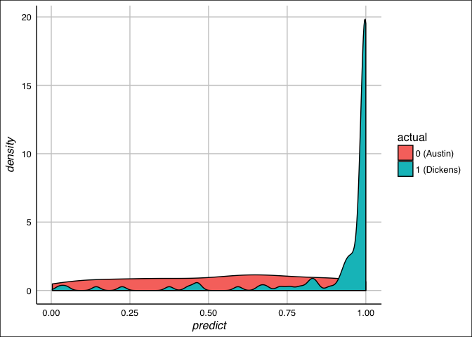

```r
y <- test$author
predict = predict.glm(model, test, type = 'response')
results = data.frame(actual = as.factor(ifelse(y == 0, '0 (Austin)', '1 (Dickens)')), predict)
ggplot(results, aes(x = predict, fill = actual, group = actual)) +
  geom_density()
```

```r
TP <- sum(predict >= cutoff[bestIndex] & y == 1)
TN <- sum(predict < cutoff[bestIndex] & y == 0)
paste('Error:',1 - (TP + TN) / length(predict))
```

```
## [1] "Error: 0.292079207920792"
```